# Exercise 3

Risiko sistemik perbankan adalah keadaan dimana kejadian bangkrutnya suatu bank yang mendorong kejatuhan industry perbankan secara nasional. Anda adalah seorang data analist di pemerintahan yang ingin menyelidiki kontribusi suatu bank dalam risiko sistemik dan faktor-faktor apa yang mempengaruhi tingkat risiko sistemik suatu bank tersebut, terutama apakah besarnya Bank dan tingkat persaingan pasar mempengaruhi tingkat risiko sistemik suatu bank. Anda telah mengumpulkan data-data sebagai berikut. Anda harus menulis program python dengan menggunakan machine learning untuk melakukan analisa data tersebut dan memberikan kesimpulan berupa insight atas berbagai variable di bawah.

1. Kontribusi bank terhadap risiko sistemik suatu system keuangan berada pada kolom DCOVAR (Delta Conditional Value at Risk).
2. CR5 adalah rasio konsentrasi perbankan, diukur berdasarkan konsentrasi asset lima bank terbesar.
3. Competition adalah rasio tingkat persaingan bank pada suatu waktu.

Below is the package load and installation.

```python
import sys

#!{sys.executable} -m pip install numpy
#!{sys.executable} -m pip install pandas
#!{sys.executable} -m pip install -U matplotlib
#!{sys.executable} -m pip install seaborn
#!{sys.executable} -m pip install -U scikit-learn
#!{sys.executable} -m pip install statsmodels
#!{sys.executable} -m pip install catboost

import re
import copy
import math
import warnings
from collections import defaultdict

import numpy as np
import pandas as pd

import scipy.stats as stats

from sklearn.preprocessing import (
    Normalizer
)

import statsmodels.api as sm

import matplotlib.pyplot as plt
import seaborn as sns
```

Load the excel sheet.

```python
# Import dataset.
df = pd.read_excel(
    "data/Systemic Risk Data Panel.xls",
    sheet_name="Sheet1"
)
```

Fix the column names.

```python
def process_column_names(
        df: pd.DataFrame
):
    # First row to column name if possible.
    new_columns = [x if isinstance(x, str) else y for y, x in zip(df.columns, df.loc[0, :].tolist())]
    # Change unnamed to undefined.
    new_columns = ["undefined" if re.search("Unnamed: ", x) else x for x in new_columns]
    const = copy.deepcopy(new_columns)

    # Unique counter.
    counter = defaultdict(int)

    # Process all columns.
    for i, col in enumerate(new_columns):
        # Only process non uniques.
        if const.count(col) > 1:
            # Rename column.
            new_columns[i] = col + f"_{counter[col]}"
            # Increment counter.
            counter[col] += 1

    return new_columns

# Process column names.
df.columns = process_column_names(df)

# Drop concatenation column.
df = df.drop(["undefined_0"], axis=1)
```

Since the data has some missing values, below is the code to impute the dataset per bank institution with linear interpolation. We also fixed some bank names and separate the year and month as categorical variable that could give insight on the dataset. Finally, we are going to drop some constant variables because they will be bad for hypothesis testing and regression analysis.

```python
# Convert dtypes.
df = df.convert_dtypes()

# List of df.
df_list = []

# Create year and month.
year_month = [re.split('M', x) for x in df[df["Bank"] == "_MNC"]["Period"]]
total_year_month = len(year_month)
year = [int(x[0]) for x in year_month]
month = [int(x[1]) for x in year_month]

# Separate by bank for null imputation with interpolation.
for bank in df["Bank"].unique()[1:]:
    # Filter by bank.
    new_df = df[df["Bank"] == bank]
    # Drop bank and date, reset index.
    new_df = new_df.drop(["Bank", "Period"], axis=1).reset_index(drop=True)
    # Interpolate.
    with warnings.catch_warnings():
        warnings.simplefilter("ignore")
        new_df = new_df.interpolate()
    # Save columns.
    columns = new_df.columns
    # Process bank and date.
    new_df["bank"] = [re.sub('_', '', bank) for _ in range(total_year_month)]
    new_df["year"] = year
    new_df["month"] = month
    # Rearrange column.
    new_df = new_df[["bank", "year", "month"] + list(columns)]
    # Set to list of banks.
    df_list.append(new_df)

# Concatenate dataframe.
df = pd.concat(df_list)
df = df.dropna()

# Drop constant columns.
df = df.loc[:, (df != df.iloc[0]).any()]
```

We will assume that DCOVAR, CR5, and Competition are dependent or target variables. The rest will be used as our training and testing data. We will remove the year, and one-hot-encode the month variable.

```python
# Separate X and y.
target_columns = ["dcovar", "CR5", "Competition"]
df_data = df[[col for col in df.columns if col not in target_columns]]
df_target = df[target_columns]

# One hot encode month.
one_hot = pd.get_dummies(df_data["month"], dtype=int).drop(12, axis=1)
one_hot.columns = [f"month_{x}" for x in one_hot.columns]
df_data = pd.concat(
    [df_data.reset_index(drop=True), one_hot.reset_index(drop=True)],
    axis=1
)

# Drop columns.
df_data = df_data.drop(["year", "month"], axis=1)

# Convert dtypes.
df_data = df_data.convert_dtypes()
df_target = df_target.convert_dtypes()
```

Some functions that will help with the analysis.

```python
def process_X(
        df_data: pd.DataFrame,
        df_data_test: pd.DataFrame = None,
        normalise: bool = True
):
    """
    Process df_data to X data.
    """
    df_data = df_data.select_dtypes(include="number", )

    X_train = df_data.to_numpy()
    if df_data_test is not None:
        df_data_test = df_data_test.select_dtypes(include="number", )
        X_test = df_data_test.to_numpy()

    # Normalise.
    if normalise:
        normaliser = Normalizer().fit(X_train)
        X_train = normaliser.transform(X_train)
        if df_data_test is not None:
            X_test = normaliser.transform(X_test)

    if df_data_test is None:
        return X_train
    else:
        return X_train, X_test

def get_ols_summary(
        X: np.ndarray,
        y: np.ndarray,
        columns: list,
        return_result: bool = False
):
    """
    Get OLS summary.
    """
    # Get the ordinary least squares analysis.
    model = sm.OLS(y, X)
    res = model.fit()

    # Produce the summary.
    data = {
        "variable": columns,
        "coef": res.params,
        "std err": res.bse,
        "t": res.tvalues,
        "P>|t|": res.pvalues,
        "significant": [True if x < 0.05 else False for x in res.pvalues]
    }

    if return_result:
        return pd.DataFrame(data), res
    else:
        return pd.DataFrame(data)

def summary_ols(
        df_res: pd.DataFrame
):
    """
    Text summary.
    """

    text = "OLS Summary \n\n"
    text += '\n' + ('=' * 100) + '\n'

    # Find out how many significant variables.
    text += str(df_res["significant"].value_counts())

    text += '\n' + ('=' * 100) + '\n'

    # Filter only significant.
    df_res = df_res[df_res["significant"] == True]
    text += '\n' + "Significant variables:" + '\n'
    for variable in df_res["variable"].tolist():
        text += variable + '\n'

    return text
```

## DCOVAR

We will start with a Ordinary Least Squares analysis on the DCOVAR.

All train data will be normalised.

```python
# Initial training.
X = process_X(
    df_data=df_data,
)
y = df_target["dcovar"].to_numpy()

df_res, result = get_ols_summary(X, y, df_data.columns[1:], return_result=True)
print(df_res)
print(result.summary())
```

```
       variable      coef   std err         t         P>|t|  significant
0           C_0 -0.035516  0.005489 -6.470575  1.273404e-10         True
1           C_1  0.021396  0.009481  2.256682  2.415445e-02         True
2     RIHSG_1_0 -0.060540  0.025254 -2.397258  1.662566e-02         True
3     RIHSG_1_1 -0.023849  0.021349 -1.117114  2.641032e-01        False
4   RBIRATE_1_0  0.036321  0.009763  3.720362  2.054034e-04         True
..          ...       ...       ...       ...           ...          ...
78      month_7  0.007695  0.047805  0.160966  8.721391e-01        False
79      month_8  0.008128  0.047287  0.171890  8.635447e-01        False
80      month_9  0.007312  0.047320  0.154524  8.772147e-01        False
81     month_10 -0.002737  0.016655 -0.164312  8.695052e-01        False
82     month_11 -0.002551  0.016992 -0.150131  8.806794e-01        False

[83 rows x 6 columns]
                                 OLS Regression Results
=======================================================================================
Dep. Variable:                      y   R-squared (uncentered):                   0.963
Model:                            OLS   Adj. R-squared (uncentered):              0.962
Method:                 Least Squares   F-statistic:                              893.3
Date:                Mon, 26 Aug 2024   Prob (F-statistic):                        0.00
Time:                        17:30:49   Log-Likelihood:                          6252.2
No. Observations:                1749   AIC:                                 -1.241e+04
Df Residuals:                    1700   BIC:                                 -1.214e+04
Df Model:                          49
Covariance Type:            nonrobust
==============================================================================
                 coef    std err          t      P>|t|      [0.025      0.975]
------------------------------------------------------------------------------
x1            -0.0355      0.005     -6.471      0.000      -0.046      -0.025
x2             0.0214      0.009      2.257      0.024       0.003       0.040
x3            -0.0605      0.025     -2.397      0.017      -0.110      -0.011
x4            -0.0238      0.021     -1.117      0.264      -0.066       0.018
x5             0.0363      0.010      3.720      0.000       0.017       0.055
x6             0.0272      0.011      2.391      0.017       0.005       0.050
x7             0.0005      0.014      0.034      0.973      -0.027       0.028
x8            -0.1149      0.014     -8.338      0.000      -0.142      -0.088
x9             0.0010      0.001      1.122      0.262      -0.001       0.003
x10            0.0372      0.010      3.852      0.000       0.018       0.056
x11           -0.0126      0.017     -0.739      0.460      -0.046       0.021
x12            0.0315      0.021      1.496      0.135      -0.010       0.073
```

[output cut: 68 more lines]

```
x81            0.0073      0.047      0.155      0.877      -0.086       0.100
x82           -0.0027      0.017     -0.164      0.870      -0.035       0.030
x83           -0.0026      0.017     -0.150      0.881      -0.036       0.031
==============================================================================
Omnibus:                      707.235   Durbin-Watson:                   1.530
Prob(Omnibus):                  0.000   Jarque-Bera (JB):           112599.210
Skew:                          -0.790   Prob(JB):                         0.00
Kurtosis:                      42.276   Cond. No.                     2.52e+17
==============================================================================

Notes:
[1] R² is computed without centering (uncentered) since the model does not contain a constant.
[2] Standard Errors assume that the covariance matrix of the errors is correctly specified.
[3] The smallest eigenvalue is 2.32e-32. This might indicate that there are
strong multicollinearity problems or that the design matrix is singular.
```

```python
# Get the summary.
print(summary_ols(df_res))
```

```
OLS Summary


====================================================================================================
significant
False    47
True     36
Name: count, dtype: int64
====================================================================================================

Significant variables:
C_0
C_1
RIHSG_1_0
RBIRATE_1_0
RBIRATE_1_1
RKURS_1_1
VOL_KURS_1_1
RIHSG_1_3
RBIRATE_1_2
RBIRATE_1_3
RKURS_1_2
RKURS_1_3
C_4
C_5
RI_1
RIHSG_1_4
RBIRATE_1_5
RKURS_1_4
RKURS_1_5
VOL_KURS_1_4
VOL_KURS_1_5
RJIBOR_1_4
C_6
C_7
RIHSG_1_6
RIHSG_1_7
RBIRATE_1_7
RKURS_1_7
rIHSG_1
rKurs_1
Vol_Kurs_1
rJIBOR_1
undefined_1
undefined_2
undefined_3
SIZE
```

Let's compare the DCOVAR over time with different bank to understand the value.

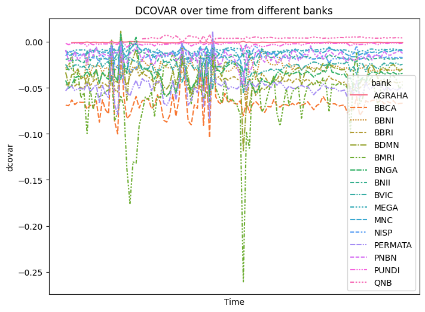

```python
# See the time distribution.
df_new = copy.deepcopy(df)
df_new["concatenate"] = [f"{year}_{month}" for year, month in zip(df["year"], df["month"])]
dict_value = {x: i for i, x in enumerate(df_new["concatenate"].unique())}
df_new["concatenate"] = [dict_value[x] for x in df_new["concatenate"]]

df_wide = df_new.pivot(
    index="concatenate",
    columns="bank",
    values="dcovar"
)

fig, ax = plt.subplots(1, 1, figsize=(8, 6))

ax = sns.lineplot(
    data=df_wide,
    ax=ax
)

plt.xticks([])
ax.set_title("DCOVAR over time from different banks")
ax.set_xlabel("Time")
ax.set_ylabel("dcovar")
```

From the plot, we can see that at some month the "dcovar" are skewed to the left. The value has a low variability for most of the time; however, there are periods where the DCOVAR drops, and some banks are more affected than the other.

To understand more, let's analyse variables that are significant and mostly correlated to DCOVAR. In this case, we will use the Spearman's correlation since the plot shows non-parametric behaviour on some point in time.

```python
# Dictionary.
data_dict = defaultdict(list)

# Calculate correlation.
for variable in df_res[df_res["significant"] == True]["variable"].tolist():
    corr, _ = stats.spearmanr(df_target["dcovar"].to_numpy(), df_data[variable].to_numpy())
    data_dict["variable"].append(variable)
    data_dict["corr"].append(corr)
    data_dict["abs"].append(np.abs(corr))

# To dataframe.
df_corr = pd.DataFrame(data_dict)

# Sort.
df_corr = df_corr.sort_values(by="abs", ascending=False, ignore_index=True)

# Get top 5 correlation.
print(df_corr.head(5))
```

```
      variable      corr       abs
0    RIHSG_1_4  0.815163  0.815163
1  undefined_3  0.805433  0.805433
2         RI_1  0.800246  0.800246
3         SIZE -0.711788  0.711788
4    RIHSG_1_6  0.423351  0.423351
```

Korelasi yang paling kuat untuk resiko sistemik sistem keuangan adalah tingkat pengembalian hasil indeks harga gabungan. Ketika RIHSG jatuh, maka DCOVAR juga akan jatuh. Saya kurang tahu untuk variable RI, tetapi variable itu berpengaruh juga terhadap DCOVAR dan berbeda dari semua bank. Berikut DCOVAR untuk data.

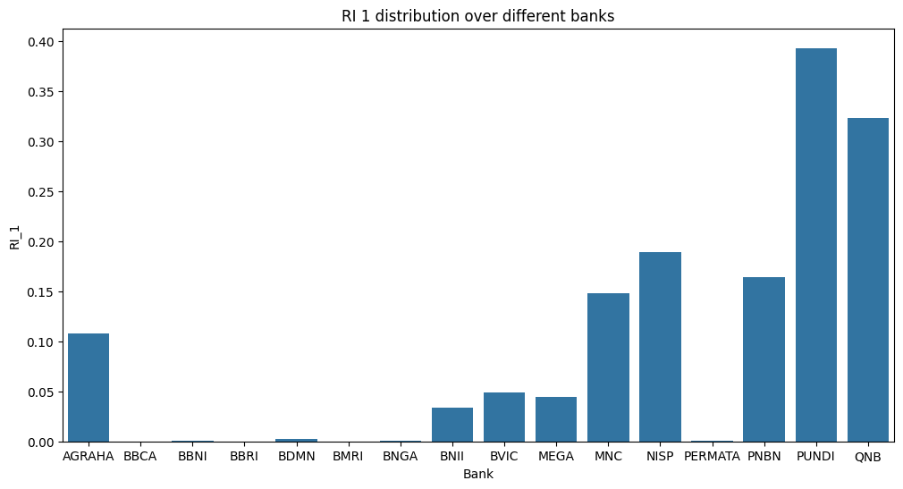

```python
# Plot.
fig, ax = plt.subplots(1, 1, figsize=(12, 6))

ax = sns.barplot(
    data=df.groupby("bank")["RI_1"].median(),
    ax=ax
)

ax.set_title("RI 1 distribution over different banks")
ax.set_xlabel("Bank")
ax.set_ylabel("RI_1")
```

The RI_1 variable has a wide variance between banks. To understand more, let's move to the size of the each bank.

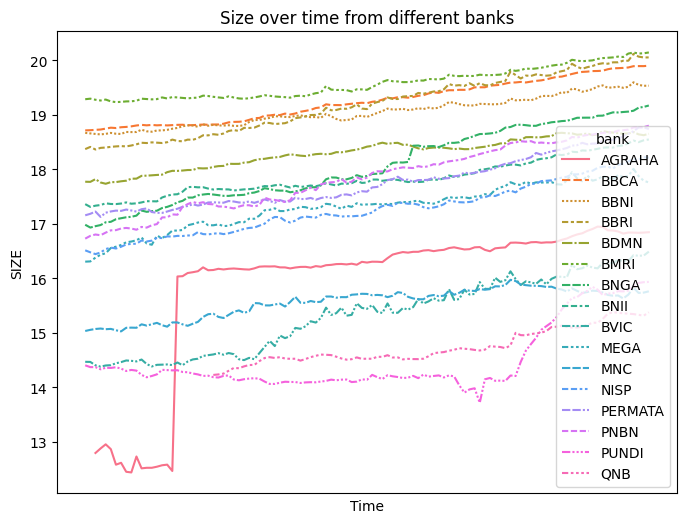

```python
df_wide = df_new.pivot(
    index="concatenate",
    columns="bank",
    values="SIZE"
)

fig, ax = plt.subplots(1, 1, figsize=(8, 6))

ax = sns.lineplot(
    data=df_wide,
    ax=ax
)

plt.xticks([])
ax.set_title("Size over time from different banks")
ax.set_xlabel("Time")
ax.set_ylabel("SIZE")
```

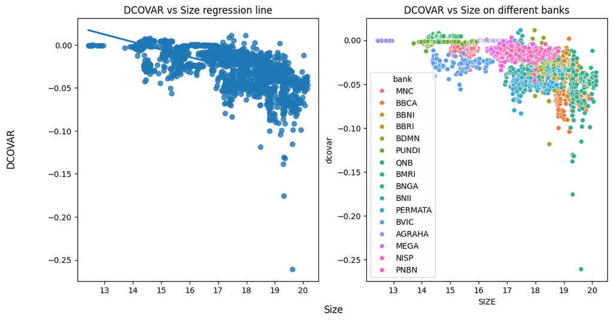

```python
# Plot.
fig, axs = plt.subplots(1, 2, figsize=(12, 6))

try:
    sns.regplot(
        data=df,
        x="SIZE",
        y="dcovar",
        ax=axs[0]
    )
except:
    pass

axs[0].set_title("DCOVAR vs Size regression line")

ax = sns.scatterplot(
    data=df,
    x="SIZE",
    y="dcovar",
    hue="bank",
    ax=axs[1]
)

axs[1].set_title("DCOVAR vs Size on different banks")

fig.supxlabel("Size")
fig.supylabel("DCOVAR")

plt.show()
```

```python
# Group by object.
groupby_object = df.groupby("bank")
df_dcovar_size = pd.DataFrame({
    "dcovar": groupby_object["dcovar"].mean(),
    "size": groupby_object["SIZE"].mean()
})

df_dcovar_size = df_dcovar_size.sort_values("size", ascending=False)
print(df_dcovar_size)

df_dcovar_size = df_dcovar_size.sort_values("dcovar", ascending=True)
print(df_dcovar_size)
```

```
           dcovar       size
bank
BMRI    -0.058537  19.579978
BBCA    -0.066998  19.252434
BBRI     -0.04327  19.185922
BBNI    -0.028746  19.056923
BDMN    -0.035763  18.299526
BNGA    -0.035037  18.068006
PNBN    -0.015985  17.841554
BNII    -0.017109  17.840817
PERMATA  -0.04874  17.758386
MEGA    -0.009232  17.308167
NISP    -0.016038  17.263962
AGRAHA   -0.00061  15.892262
MNC      -0.01159  15.554113
BVIC    -0.027301   15.31902
QNB      0.004211  14.743685
PUNDI    -0.00255  14.487927
           dcovar       size
bank
BBCA    -0.066998  19.252434
BMRI    -0.058537  19.579978
PERMATA  -0.04874  17.758386
BBRI     -0.04327  19.185922
BDMN    -0.035763  18.299526
BNGA    -0.035037  18.068006
BBNI    -0.028746  19.056923
BVIC    -0.027301   15.31902
BNII    -0.017109  17.840817
NISP    -0.016038  17.263962
PNBN    -0.015985  17.841554
MNC      -0.01159  15.554113
MEGA    -0.009232  17.308167
PUNDI    -0.00255  14.487927
AGRAHA   -0.00061  15.892262
QNB      0.004211  14.743685
```

Dari hasil di atas, kita dapat melihat bahwa bank BMRI dan BCA memiliki kontribusi resiko sistemik terendah dan asset terbanyak. Namun bank Permata walau tidak memiliki asset sebanyak bank BBRI atau BBNI, resiko sistemiknya lebih rendah dari bank-bank tersebut.

## CR5

```python
# CR5
y = df_target["CR5"].to_numpy()

df_res, result = get_ols_summary(X, y, df_data.columns[1:], return_result=True)
print(df_res)
print(result.summary())
```

```
       variable      coef   std err          t         P>|t|  significant
0           C_0 -0.663320  0.010823 -61.290277  0.000000e+00         True
1           C_1  1.392185  0.018695  74.469440  0.000000e+00         True
2     RIHSG_1_0  0.011448  0.049794   0.229906  8.181921e-01        False
3     RIHSG_1_1  0.436793  0.042094  10.376580  1.678134e-24         True
4   RBIRATE_1_0  0.301504  0.019250  15.662677  9.415033e-52         True
..          ...       ...       ...        ...           ...          ...
78      month_7 -0.453401  0.094259  -4.810147  1.641455e-06         True
79      month_8 -0.516934  0.093237  -5.544287  3.416005e-08         True
80      month_9 -0.549278  0.093303  -5.887041  4.727133e-09         True
81     month_10 -0.186598  0.032840  -5.682099  1.562424e-08         True
82     month_11 -0.159942  0.033504  -4.773813  1.962675e-06         True

[83 rows x 6 columns]
                                 OLS Regression Results
=======================================================================================
Dep. Variable:                      y   R-squared (uncentered):                   0.999
Model:                            OLS   Adj. R-squared (uncentered):              0.999
Method:                 Least Squares   F-statistic:                          5.028e+04
Date:                Mon, 26 Aug 2024   Prob (F-statistic):                        0.00
Time:                        17:30:50   Log-Likelihood:                          5064.7
No. Observations:                1749   AIC:                                 -1.003e+04
Df Residuals:                    1700   BIC:                                     -9764.
Df Model:                          49
Covariance Type:            nonrobust
==============================================================================
                 coef    std err          t      P>|t|      [0.025      0.975]
------------------------------------------------------------------------------
x1            -0.6633      0.011    -61.290      0.000      -0.685      -0.642
x2             1.3922      0.019     74.469      0.000       1.356       1.429
x3             0.0114      0.050      0.230      0.818      -0.086       0.109
x4             0.4368      0.042     10.377      0.000       0.354       0.519
x5             0.3015      0.019     15.663      0.000       0.264       0.339
x6             0.1914      0.022      8.522      0.000       0.147       0.235
x7            -0.2378      0.028     -8.551      0.000      -0.292      -0.183
x8            -2.3759      0.027    -87.475      0.000      -2.429      -2.323
x9            -0.3086      0.002   -182.846      0.000      -0.312      -0.305
x10            0.9616      0.019     50.444      0.000       0.924       0.999
x11            2.5506      0.033     76.193      0.000       2.485       2.616
x12           -0.1926      0.042     -4.638      0.000      -0.274      -0.111
```

[output cut: 68 more lines]

```
x81           -0.5493      0.093     -5.887      0.000      -0.732      -0.366
x82           -0.1866      0.033     -5.682      0.000      -0.251      -0.122
x83           -0.1599      0.034     -4.774      0.000      -0.226      -0.094
==============================================================================
Omnibus:                      131.073   Durbin-Watson:                   0.415
Prob(Omnibus):                  0.000   Jarque-Bera (JB):              184.720
Skew:                           0.615   Prob(JB):                     7.74e-41
Kurtosis:                       4.010   Cond. No.                     2.52e+17
==============================================================================

Notes:
[1] R² is computed without centering (uncentered) since the model does not contain a constant.
[2] Standard Errors assume that the covariance matrix of the errors is correctly specified.
[3] The smallest eigenvalue is 2.32e-32. This might indicate that there are
strong multicollinearity problems or that the design matrix is singular.
```

The R-squared shows that all variables accounts to 99 % variance of the CR5. That is because we include the size of the bank as training data, and they are part of the CR5 equation.

```python
# Get the summary.
print(summary_ols(df_res))
```

```
OLS Summary


====================================================================================================
significant
True     73
False    10
Name: count, dtype: int64
====================================================================================================

Significant variables:
C_0
C_1
RIHSG_1_1
RBIRATE_1_0
RBIRATE_1_1
RKURS_1_0
RKURS_1_1
VOL_KURS_1_0
VOL_KURS_1_1
RJIBOR_1_0
RJIBOR_1_1
C_2
C_3
RIHSG_1_2
RIHSG_1_3
RBIRATE_1_2
RBIRATE_1_3
RKURS_1_2
RKURS_1_3
C_4
C_5
RI_0
RI_1
RIHSG_1_4
RIHSG_1_5
RBIRATE_1_4
RBIRATE_1_5
RKURS_1_4
RKURS_1_5
```

[output cut: 29 more lines]

```
SIZE
OI
OI'
ROA
ROA'
EQ
month_3
month_4
month_5
month_6
month_7
month_8
month_9
month_10
month_11
```

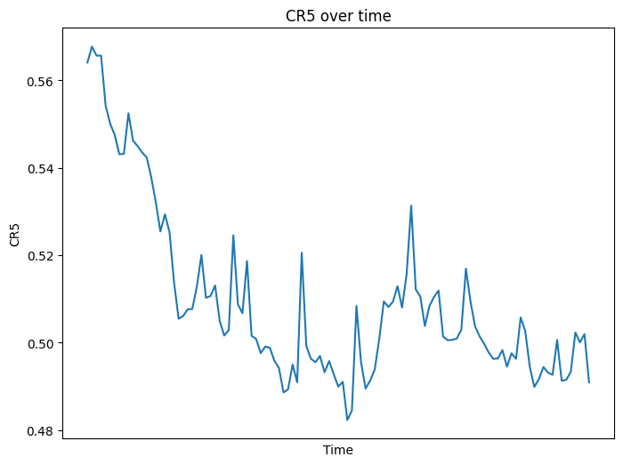

```python
fig, ax = plt.subplots(1, 1, figsize=(8, 6))

ax = sns.lineplot(
    data=df[df["bank"] == "BBCA"],
    x=range(len(df[df["bank"] == "BBCA"].index)),
    y="CR5",
    ax=ax
)

plt.xticks([])
ax.set_title("CR5 over time")
ax.set_xlabel("Time")
ax.set_ylabel("CR5")
```

Unlike DCOVAR, the CR5 variable only takes the biggest five banks. Let's do a Spearman's correlation.

```python
# Dictionary.
data_dict = defaultdict(list)

# Calculate correlation.
for variable in df_res[df_res["significant"] == True]["variable"].tolist():
    corr, _ = stats.spearmanr(df_target["CR5"].to_numpy(), df_data[variable].to_numpy())
    data_dict["variable"].append(variable)
    data_dict["corr"].append(corr)
    data_dict["abs"].append(np.abs(corr))

# To dataframe.
df_corr = pd.DataFrame(data_dict)

# Sort.
df_corr = df_corr.sort_values(by="abs", ascending=False, ignore_index=True)

# Get top 5 correlation.
print(df_corr.head(5))
```

```
  variable      corr       abs
0       LO -0.262272  0.262272
1      LLP  0.253307  0.253307
2      LDR -0.231679  0.231679
3     SIZE -0.136669  0.136669
4       EQ -0.135647  0.135647
```

The correlation between the variables and the CR5 variables are significantly small. Each variable explained only by a little for the CR5 variable. The most important factor is the loan to total asset ratio, provision to loan ratio, loan to deposit ratio, and bank size. However, these correlation are very weak.

Next, I tried to widen the dataset.

```python
# Create wide dataset.
df_list = []
for bank in df_data["bank"].unique():
    df_temp = df_data[df_data["bank"] == bank]
    df_temp = df_temp.drop(columns="bank")
    df_temp.columns = [f"{bank}_{col}" for col in df_temp.columns]
    df_temp = df_temp.reset_index(drop=True)
    df_list.append(df_temp)

df_data_wide = pd.concat(df_list, axis=1)
df_data_wide = df_data_wide.T.drop_duplicates().T.convert_dtypes()
df_data_wide = df_data_wide.interpolate()


X = process_X(df_data_wide)
y = df[df["bank"] == "BBCA"]["CR5"].to_numpy()

df_res, result = get_ols_summary(X, y, df_data_wide.columns, return_result=True)
print(df_res)
print(result.summary())
```

```
             variable      coef  std err    t  P>|t|  significant
0             MNC_C_0  0.005537      inf  0.0    NaN        False
1             MNC_C_1 -0.000182      inf -0.0    NaN        False
2       MNC_RIHSG_1_0 -0.023316      inf -0.0    NaN        False
3       MNC_RIHSG_1_1 -0.001535      inf -0.0    NaN        False
4     MNC_RBIRATE_1_0  0.018552      inf  0.0    NaN        False
...               ...       ...      ...  ...    ...          ...
998         PNBN_SIZE -2.096495      inf -0.0    NaN        False
999           PNBN_OI  0.533996      inf  0.0    NaN        False
1000         PNBN_ROA  0.527549      inf  0.0    NaN        False
1001        PNBN_ROA'  0.109254      inf  0.0    NaN        False
1002          PNBN_EQ -2.349894      inf -0.0    NaN        False

[1003 rows x 6 columns]
                            OLS Regression Results
==============================================================================
Dep. Variable:                      y   R-squared:                       1.000
Model:                            OLS   Adj. R-squared:                    nan
Method:                 Least Squares   F-statistic:                       nan
Date:                Mon, 26 Aug 2024   Prob (F-statistic):                nan
Time:                        17:30:51   Log-Likelihood:                 3269.5
No. Observations:                 111   AIC:                            -6317.
Df Residuals:                       0   BIC:                            -6016.
Df Model:                         110
Covariance Type:            nonrobust
==============================================================================
                 coef    std err          t      P>|t|      [0.025      0.975]
------------------------------------------------------------------------------
x1             0.0055        inf          0        nan         nan         nan
x2            -0.0002        inf         -0        nan         nan         nan
x3            -0.0233        inf         -0        nan         nan         nan
x4            -0.0015        inf         -0        nan         nan         nan
x5             0.0186        inf          0        nan         nan         nan
x6            -0.0105        inf         -0        nan         nan         nan
x7             0.0458        inf          0        nan         nan         nan
x8            -0.0169        inf         -0        nan         nan         nan
x9             0.3166        inf          0        nan         nan         nan
x10           -0.0157        inf         -0        nan         nan         nan
x11           -0.0038        inf         -0        nan         nan         nan
x12           -0.0187        inf         -0        nan         nan         nan
```

[output cut: 988 more lines]

```
x1000          0.5275        inf          0        nan         nan         nan
x1001          0.1093        inf          0        nan         nan         nan
x1002         -2.3499        inf         -0        nan         nan         nan
==============================================================================
Omnibus:                        1.526   Durbin-Watson:                   0.005
Prob(Omnibus):                  0.466   Jarque-Bera (JB):                1.015
Skew:                           0.134   Prob(JB):                        0.602
Kurtosis:                       3.384   Cond. No.                     3.77e+04
==============================================================================

Notes:
[1] Standard Errors assume that the covariance matrix of the errors is correctly specified.
[2] The input rank is higher than the number of observations.
[3] The condition number is large, 3.77e+04. This might indicate that there are
strong multicollinearity or other numerical problems.
```

As we can see, there is an indication of multicollinearity between the banks. If we have more time, this would be explored. We would know which variable from which bank has the significance to the CR5.

```python
# Spearman correlation.
data_dict = defaultdict(list)

# Calculate correlation.
for variable in df_data_wide.columns:
    with warnings.catch_warnings():
        warnings.simplefilter("ignore")
        corr, _ = stats.spearmanr(y, df_data_wide[variable].to_numpy())
    data_dict["variable"].append(variable)
    data_dict["corr"].append(corr)
    data_dict["abs"].append(np.abs(corr))

# To dataframe.
df_corr = pd.DataFrame(data_dict).dropna()

# Sort.
df_corr = df_corr.sort_values(by="abs", ascending=False, ignore_index=True)

# Get top 5 correlation.
print(df_corr.head(10))
```

```
    variable      corr       abs
0    PNBN_LO -0.731906  0.731906
1   BDMN_LLP  0.712022  0.712022
2  BDMN_SIZE -0.670463  0.670463
3   BVIC_LLP  0.647157  0.647157
4    BBCA_LO -0.647087  0.647087
5   BNGA_LDR -0.644989  0.644989
6   BBCA_LDR -0.639145  0.639145
7   PNBN_LDR -0.637522  0.637522
8   BNII_LDR -0.637276  0.637276
9   PNBN_LLP  0.628299  0.628299
```

Although the CR5 should only take into account the biggest banks, intrinsic factor from smaller banks might have a decent correlation. Similar trend where loan to total asset has a negative correlation, while the provision to loan ratio has a positive correlation.

## Competition

```python
# Competition
X = process_X(df_data)
y = df_target["Competition"].to_numpy()

df_res, result = get_ols_summary(X, y, df_data.columns[1:], return_result=True)
print(df_res)
print(result.summary())
```

```
       variable      coef   std err          t          P>|t|  significant
0           C_0 -1.040134  0.028837 -36.069664  4.685521e-212         True
1           C_1  2.487276  0.049812  49.933206   0.000000e+00         True
2     RIHSG_1_0 -0.506359  0.132677  -3.816487   1.402143e-04         True
3     RIHSG_1_1  1.203409  0.112160  10.729425   4.940432e-26         True
4   RBIRATE_1_0  0.791429  0.051291  15.430142   2.259628e-50         True
..          ...       ...       ...        ...            ...          ...
78      month_7  0.800136  0.251154   3.185841   1.469534e-03         True
79      month_8  0.762420  0.248431   3.068945   2.182114e-03         True
80      month_9  0.592205  0.248606   2.382104   1.732347e-02         True
81     month_10  0.506323  0.087501   5.786469   8.540381e-09         True
82     month_11  0.347353  0.089271   3.890976   1.036929e-04         True

[83 rows x 6 columns]
                                 OLS Regression Results
=======================================================================================
Dep. Variable:                      y   R-squared (uncentered):                   0.998
Model:                            OLS   Adj. R-squared (uncentered):              0.998
Method:                 Least Squares   F-statistic:                          2.032e+04
Date:                Mon, 26 Aug 2024   Prob (F-statistic):                        0.00
Time:                        17:30:51   Log-Likelihood:                          3350.7
No. Observations:                1749   AIC:                                     -6603.
Df Residuals:                    1700   BIC:                                     -6336.
Df Model:                          49
Covariance Type:            nonrobust
==============================================================================
                 coef    std err          t      P>|t|      [0.025      0.975]
------------------------------------------------------------------------------
x1            -1.0401      0.029    -36.070      0.000      -1.097      -0.984
x2             2.4873      0.050     49.933      0.000       2.390       2.585
x3            -0.5064      0.133     -3.816      0.000      -0.767      -0.246
x4             1.2034      0.112     10.729      0.000       0.983       1.423
x5             0.7914      0.051     15.430      0.000       0.691       0.892
x6             0.1894      0.060      3.165      0.002       0.072       0.307
x7            -0.5392      0.074     -7.277      0.000      -0.685      -0.394
x8            -3.7245      0.072    -51.465      0.000      -3.866      -3.583
x9            -0.5269      0.004   -117.153      0.000      -0.536      -0.518
x10            1.4621      0.051     28.786      0.000       1.362       1.562
x11            4.3491      0.089     48.760      0.000       4.174       4.524
x12           -0.7730      0.111     -6.985      0.000      -0.990      -0.556
```

[output cut: 68 more lines]

```
x81            0.5922      0.249      2.382      0.017       0.105       1.080
x82            0.5063      0.088      5.786      0.000       0.335       0.678
x83            0.3474      0.089      3.891      0.000       0.172       0.522
==============================================================================
Omnibus:                      188.232   Durbin-Watson:                   0.529
Prob(Omnibus):                  0.000   Jarque-Bera (JB):              254.011
Skew:                          -0.860   Prob(JB):                     6.95e-56
Kurtosis:                       3.726   Cond. No.                     2.52e+17
==============================================================================

Notes:
[1] R² is computed without centering (uncentered) since the model does not contain a constant.
[2] Standard Errors assume that the covariance matrix of the errors is correctly specified.
[3] The smallest eigenvalue is 2.32e-32. This might indicate that there are
strong multicollinearity problems or that the design matrix is singular.
```

The R-squared shows that all variables accounts to 99.8 % variance of the Competition.

```python
# Get the summary.
print(summary_ols(df_res))
```

```
OLS Summary


====================================================================================================
significant
True     66
False    17
Name: count, dtype: int64
====================================================================================================

Significant variables:
C_0
C_1
RIHSG_1_0
RIHSG_1_1
RBIRATE_1_0
RBIRATE_1_1
RKURS_1_0
RKURS_1_1
VOL_KURS_1_0
VOL_KURS_1_1
RJIBOR_1_0
RJIBOR_1_1
C_2
C_3
RIHSG_1_2
RIHSG_1_3
RBIRATE_1_2
RBIRATE_1_3
RKURS_1_2
RKURS_1_3
C_4
C_5
RI_0
RI_1
RIHSG_1_4
RIHSG_1_5
RBIRATE_1_4
RBIRATE_1_5
RKURS_1_4
```

[output cut: 22 more lines]

```
OI
OI'
ROA
EQ
month_1
month_2
month_3
month_4
month_5
month_6
month_7
month_8
month_9
month_10
month_11
```

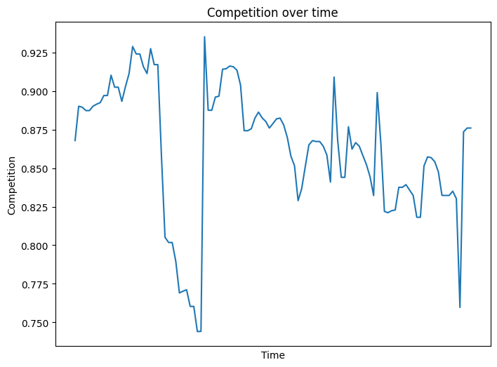

```python
fig, ax = plt.subplots(1, 1, figsize=(8, 6))

ax = sns.lineplot(
    data=df[df["bank"] == "BBCA"],
    x=range(len(df[df["bank"] == "BBCA"].index)),
    y="Competition",
    ax=ax
)

plt.xticks([])
ax.set_title("Competition over time")
ax.set_xlabel("Time")
ax.set_ylabel("Competition")
```

The data have some fluctuation over time, but generally have a small variance. Pearson or Spearman correlation could be used.

```python
# Dictionary.
data_dict = defaultdict(list)

# Calculate correlation.
for variable in df_res[df_res["significant"] == True]["variable"].tolist():
    pearson_corr, _ = stats.pearsonr(df_target["Competition"].to_numpy(), df_data[variable].to_numpy())
    spearman_corr, _ = stats.spearmanr(df_target["Competition"].to_numpy(), df_data[variable].to_numpy())
    data_dict["variable"].append(variable)
    data_dict["pearson_corr"].append(pearson_corr)
    data_dict["pearson_abs"].append(np.abs(pearson_corr))
    data_dict["spearman_corr"].append(spearman_corr)
    data_dict["spearman_abs"].append(np.abs(spearman_corr))

# To dataframe.
df_corr = pd.DataFrame(data_dict)

# Sort.
df_corr = df_corr.sort_values(by="pearson_abs", ascending=False, ignore_index=True)

# Get top 5 correlation.
print(df_corr.head(5))
```

```
    variable  pearson_corr  pearson_abs  spearman_corr  spearman_abs
0  rBIRATE_1      0.341790     0.341790       0.322879      0.322879
1   RBI Rate      0.290832     0.290832       0.415081      0.415081
2    month_1      0.131212     0.131212       0.113852      0.113852
3    rKurs_1      0.096669     0.096669       0.147482      0.147482
4      Rkurs      0.095060     0.095060       0.145263      0.145263
```

The correlation to Competition are very weak, with the BI rate has the most correlation to competition as the first and second highest correlated variable. The time of the year might have a small factor to the competition, since banks usually aim for a target before the end of a financial year.

```python
# The new data.
y = df[df["bank"] == "BBCA"]["Competition"].to_numpy()

# Spearman correlation.
data_dict = defaultdict(list)

# Calculate correlation.
for variable in df_data_wide.columns:

    with warnings.catch_warnings():
        warnings.simplefilter("ignore")
        pearson_corr, _ = stats.pearsonr(y, df_data_wide[variable].to_numpy())
        spearman_corr, _ = stats.spearmanr(y, df_data_wide[variable].to_numpy())
    data_dict["variable"].append(variable)
    data_dict["pearson_corr"].append(pearson_corr)
    data_dict["pearson_abs"].append(np.abs(pearson_corr))
    data_dict["spearman_corr"].append(spearman_corr)
    data_dict["spearman_abs"].append(np.abs(spearman_corr))

# To dataframe.
df_corr = pd.DataFrame(data_dict)

# Sort.
df_corr = df_corr.sort_values(by="pearson_abs", ascending=False, ignore_index=True)

# Get top 5 correlation.
print(df_corr.head(10))

# Sort.
df_corr = df_corr.sort_values(by="spearman_abs", ascending=False, ignore_index=True)

# Get top 5 correlation.
print(df_corr.head(10))
```

```
           variable  pearson_corr  pearson_abs  spearman_corr  spearman_abs
0     QNB_rBIRATE_1     -0.510442     0.510442      -0.568058      0.568058
1            MNC_EQ     -0.503747     0.503747      -0.467005      0.467005
2           BVIC_EQ     -0.492933     0.492933      -0.459471      0.459471
3         NISP_DDC'     -0.463592     0.463592      -0.442982      0.442982
4          NISP_DDC     -0.463592     0.463592      -0.442982      0.442982
5           BBCA_EQ     -0.448886     0.448886      -0.566723      0.566723
6  AGRAHA_rBIRATE_1      0.448665     0.448665       0.459039      0.459039
7   AGRAHA_RBI Rate      0.441694     0.441694       0.444551      0.444551
8         NISP_BDEP      0.419903     0.419903       0.346357      0.346357
9        NISP_BDEP'      0.419903     0.419903       0.346357      0.346357
        variable  pearson_corr  pearson_abs  spearman_corr  spearman_abs
0        QNB_LDR     -0.313021     0.313021      -0.591237      0.591237
1    PERMATA_LLP      0.410478     0.410478       0.588816      0.588816
2       BDMN_NPL     -0.388399     0.388399      -0.573919      0.573919
3      BDMN_NPL'     -0.388399     0.388399      -0.573919      0.573919
4  QNB_rBIRATE_1     -0.510442     0.510442      -0.568058      0.568058
5        BBCA_EQ     -0.448886     0.448886      -0.566723      0.566723
6    AGRAHA_SIZE     -0.347212     0.347212      -0.534667      0.534667
7   PERMATA_SIZE     -0.350206     0.350206      -0.524558      0.524558
8      BDMN_SIZE     -0.347938     0.347938      -0.518569      0.518569
9   QNB_RBI Rate     -0.417520     0.417520      -0.513730      0.513730
```

From the correlation values, there are some bank's BI rate linear correlation, although from smaller banks. The correlation between BI rate is a mixed between positive and negative. We can see from the spearman correlation that the intrinsic values might have a weak correlation to competition, although the factor itself might be random (different bank give different factors from LDR, LLP, NPL, SIZE). However, QNB BI rate might show a promising result in terms of decent, but not strong, correlation to the competition.

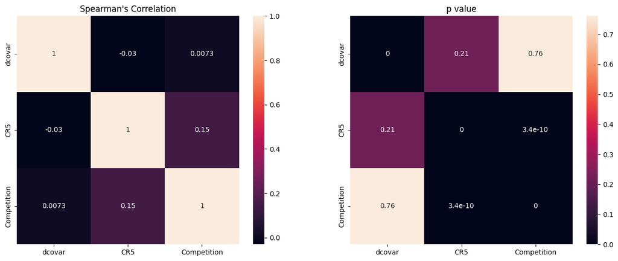

```python
array_corr = np.empty((3, 3))
array_p_value = np.empty((3, 3))

for i, col_x in enumerate(df_target.columns):
    for j, col_y in enumerate(df_target.columns):
        array_corr[i, j], array_p_value[i, j] = stats.spearmanr(
            df_target[col_x],
            df_target[col_y]
        )

fig, axs = plt.subplots(1, 2, figsize=(16, 6))

ax = sns.heatmap(
    array_corr,
    annot=True,
    xticklabels=df_target.columns,
    yticklabels=df_target.columns,
    ax=axs[0]
)

ax.set_title("Spearman's Correlation")

ax = sns.heatmap(
    array_p_value,
    annot=True,
    xticklabels=df_target.columns,
    yticklabels=df_target.columns,
    ax=axs[1]
)

ax.set_title("p value")
```

Finally, we have the correlation analysis between the target variable. DCOVAR variable is not correlated to the CR5 and competition, as CR5 and competition are mostly intrinsic factors. The CR5 and competition have a significant correlation, albeit a weak positive correlation.

## Conclusion

There are some conclusion to this dataset.

Firstly, the only intrinsic factor that affects DCOVAR is the size of the bank. Bigger bank tends to have lower DCOVAR, such as BMRI and BBCA. RIHSG and RI variable have the most impact on the DCOVAR.

The CR5 variable are mostly affected by intrinsic factors. Although in theory bigger bank should have a more defining correlation, smaller banks such as PNBN and BVIC intrinsic factor has a higher correlation than other variables (still a weak correlation). This variable might be affected by the data outside of this dataset.

Lastly, the Competition has weak correlations with the other variables. We can conclude that there is a weak correlation between Competition and rates. As for individual bank compared to Competition, both smaller and bigger bank has impact on the competition, and the size of the bank is a small factor compared to other intrinsic factor.

Finally, there is little evidence that DCOVAR is affected by CR5 or Competition.